# Computing transport coefficients with Molly.jl

SINEQ Summer School 2023

Noé Blassel

## Transport coefficients: a computational challenge

- Relate to sensitivities of **fluxes** in response to nonequilibrium **forcings** (linear response).

[figure not shown]

- **Dynamical properties** of molecular systems (thermal transport, diffusion, shear viscosity…)
- Parametrize macroscopic evolution equations (e.g. Navier–Stokes).
- Standard methods require **long simulations** to get decent estimators of these quantities.
- Need for innovative variance reduction techniques (e.g. coupling methods, synthetic forcings).
- Molly is a promising tool for testing new methods, because the total cost of learning + implementing/debugging + running simulations is low.

## Setting: nonequilibrium kinetic Langevin dynamics

- State space: $\mathcal X = \mathcal D \times {\mathbb{{R}}}^{dN}$ (positions and momenta).
- Underdamped Langevin with external forcing:
  $$\begin{equation}
  \left\{\begin{aligned}
  \mathrm{d}q_t^\eta & = \color{red}{M^{-1}p_t^\eta \mathrm{d}t}, \\
  \mathrm{d}p_t^\eta &= \color{blue}{-\nabla V(q_t^\eta)\,\mathrm{d}t} \color{green}{-\gamma M^{-1}p_t^\eta\,\mathrm{d}t +\sqrt{\frac{2\gamma}{\beta}}\mathrm{d}W_t} +\color{purple}{\eta F(q_t^\eta)\,\mathrm{d}t},
  \end{aligned}\right.
  \end{equation}$$
- Generator: $\mathcal{L}_\eta = \mathcal{L}+ \color{purple}{\eta F\cdot \nabla_p}$ with $\mathcal{L}= \color{red}{M^{-1}p\cdot \nabla_q} \color{blue}{-\nabla V\cdot \nabla_p} \color{green}{-\gamma M^{-1}p\cdot \nabla_p +\frac{\gamma}{\beta}\Delta_p}$
- Parameter: $\eta$ = strength of the perturbation.
- Steady state density: solution to the Fokker–Planck equation $\mathcal{L}_\eta^\dagger \psi_\eta = 0$.
- Forcing: $F$ not the gradient of a potential function on $\mathcal D$.
- No explicit invariant measure: $\psi_\eta(q,p)\,\mathrm{d}q\,\mathrm{d}p \neq Z_{\beta,\eta}^{-1}\mathrm{e}^{-\beta H_\eta(q,p)}\,\mathrm{d}q\,\mathrm{d}p$ except for $\eta=0$.

## Linear response

- Response observable or **flux**:
  $$R:\mathcal X \to\mathbb R.$$
- Assume:
  $$\int_{\mathcal X}R(q,p)\,\mathrm{e}^{-\beta H(q,p)}\,\mathrm{d}q\,\mathrm{d}p =0$$
  (No flux at equilibrium)
- Linear response:
  $$\begin{equation}\rho(F,R) = \underset{\eta \to 0}{\lim}\, \frac1\eta\int_{\mathcal X} R(q,p)\psi_\eta(q,p)\,\mathrm{d}q\,\mathrm{d}p
  \end{equation}$$
- Derivative of $\eta \mapsto \psi_\eta(q,p) \,\mathrm{d}q\, \mathrm{d}p$ at $0$, tested against $R$.
- For materials applications, $F$ and $R$ have very specific forms informed by physics.
- Running example: mobility. $F$ **constant**, response $R(q,p)=F\cdot M^{-1}p$, particle flux in direction $F$.

## Discretization in time

- Nonequilibrium generator:
  $$\mathcal{L}_{\eta} = \mathcal{L}^{\mathrm{A}} + \mathcal{L}^{\mathrm{B}_\eta} +\gamma\mathcal{L}^{\mathrm{O}},\\
  \begin{equation}
  \left\{
  \begin{aligned}
  \mathcal{L}^{\mathrm{A}}&=M^{-1}p\cdot \nabla_q,\\
  \mathcal{L}^{\mathrm{B}_\eta}&=\left(-\nabla V+\eta F\right)\cdot \nabla_p,\\
  \mathcal{L}^{\mathrm{O}}&=-M^{-1}p\cdot \nabla_p +\frac{1}{\beta}\Delta_p,\\
  \end{aligned}\right.
  \end{equation}$$
- As in the equilibrium case, use splitting schemes.
- Individually, these are the generators of analytically integrable dynamics.
- Example: nonequilibrium BAOAB scheme
  $$\mathrm{e}^{\frac{\Delta t}2 \mathcal{L}^{\mathrm{B}_\eta}}\mathrm{e}^{\frac{\Delta t}2 \mathcal{L}^{\mathrm{A}}}\mathrm{e}^{\Delta t\mathcal{L}^{\mathrm{O}}}\mathrm{e}^{\frac{\Delta t}2\mathcal{L}^{\mathrm{A}}}\mathrm{e}^{\frac{\Delta t}2 \mathcal{L}^{\mathrm{B}_\eta}}.$$
- Simply “ignore” $F$ is non-gradient and add it to the force: possible to abuse equilibrium integrators based on this splitting of the generator.

## NEMD method

- Finite-difference estimator of the linear response, based on an ergodic average:
  $$\widehat{\rho}(R,F)_{\eta,T} = \frac1{\eta T}\int_0^T R(q_t^\eta,p_t^\eta)\,\mathrm{d}t.$$
- In practice, replace time integral by average over $N_{\rm sim} = \lceil T/\Delta t\rceil$ steps of a numerical trajectory.
- Variance scales asymptotically as $C(R)T^{-1}\eta^{-2} \implies T > C(R)\varepsilon^{-2}\eta^{-2}$ for CIs of order $\varepsilon$ .

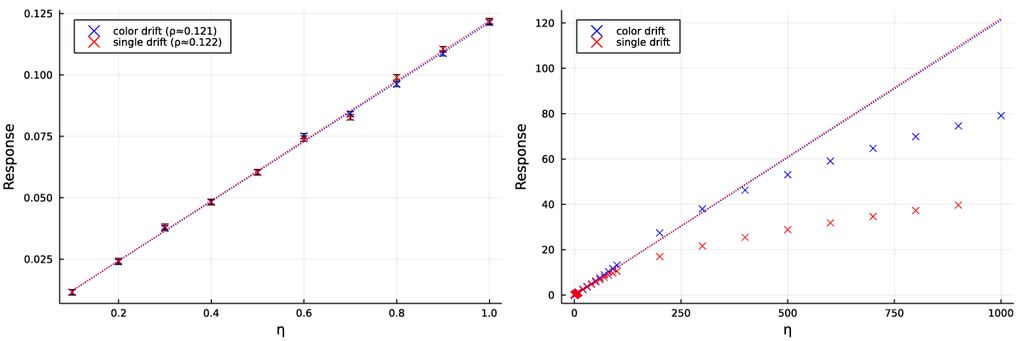

## Green–Kubo method

- Equilibrium formula:
  $$\rho(R,F) = \int_0^\infty \mathbb{E}_{\psi_0}\left[R\left(q_t,p_t\right)S\left(q_0,p_0\right)\right]\,\mathrm{d}t,\quad S = (F\cdot \nabla_p)^* {\bf 1}_{\mathcal X}.$$
- Conjugate response: $S(q,p) = \beta F(q)\cdot M^{-1}p$ (integration by parts).
- Proof by perturbative expansion $(\mathcal{L}+\eta F\cdot \nabla_p)^\dagger\left[\psi_0\left(1+\eta r_1 + \eta^2 r_2 + \dots\right)\right] = 0$.
- Estimate of correlation $\mathbb{E}_{\psi_0}\left[R\left(q_{n\Delta t},p_{n\Delta t}\right)S\left(q_0,p_0\right)\right]$ from a single trajectory:
  $$\frac{1}{N_{\rm sim}-n+1}\sum_{k=0}^{N_{\rm sim}}R(q^{n+k},p^{n+k})S(q^k,p^k),$$
  for $0\leqslant n\leqslant N_{\rm corr} \ll N_{\rm sim}$ and equilibrium $(q^0,p^0)$.
- Truncate integral in time and compute $\rho(R,F)$ with numerical quadrature (trapezoid rule).
- Extrapolate the correlations to $t\to\infty$ from short-time correlations by using cepstral analysis, *c.f.* [Bertossa, Grasselli, Ercole & Baroni, 2019](https://journals-aps-org.extranet.enpc.fr/prl/abstract/10.1103/PhysRevLett.122.255901), and integrate analytically.

## Green–Kubo method: mobility

- Mobility: Forcing $F(q) = F$, flux $R(q,p)= F\cdot M^{-1}p$, conjugate response $S(q,p) = \beta F\cdot M^{-1}p$.
- $$\rho(F,R) = \beta\int_0^\infty \mathbb{E}_{\psi_0}\left[(F\cdot M^{-1}p_t)(F\cdot M^{-1}p_0)\right]=\beta F^\intercal M^{-1} \left(\int_0^{\infty}\mathbb{E}_{\psi_0}\left[p_t\otimes p_0\right]\,\mathrm{d}t\right)M^{-1}F.$$

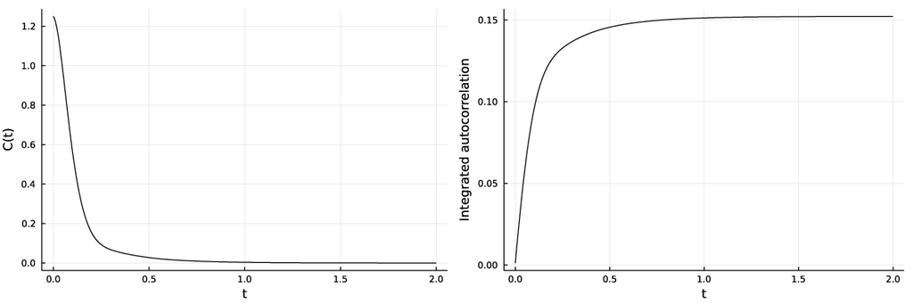

## Molly: setting up nonequilibrium system

- Setup basic Lennard–Jones fluid system

```julia
using Molly

n_atoms = 100
boundary = CubicBoundary(2.0u"nm")
temp = 298.0u"K"
atom_mass = 10.0u"g/mol"

atoms = [Atom(mass=atom_mass, σ=0.3u"nm", ϵ=0.2u"kJ * mol^-1") for i in 1:n_atoms]
coords = place_atoms(n_atoms, boundary; min_dist=0.3u"nm")
velocities = [random_velocity(atom_mass, temp) for i in 1:n_atoms]
pairwise_inters = (LennardJones(cutoff=ShiftedForceCutoff(0.8u"nm")),);
```

## Molly: setting up nonequilibrium system

To add a nonequilibrium forcing, define a custom interaction type (say `MyInterType`), and provide a method for `Molly.forces(inter::MyInterType,s::System,neighbors)` . . . -

```julia
struct MyConstantForcing{F}
  forcing::F
end

MyConstantForcing(η::Number,F) = MyConstantForcing(η * F)

Molly.forces(inter::MyConstantForcing,s::System,neighbors=nothing;kwargs...) = inter.forcing
Molly.potential_energy(inter::MyConstantForcing,s::System,neighbors=nothing;kwargs...) = zero(Unitful.numtype(eltype(sys.velocities[1])))*sys.energy_units

η = 10.0u"ps^-1" # very large forcing

const F = zero(velocities) * u"g * mol^-1 "
F[1] = SVector(1.0,0.0,0.0) * u"nm * g * mol^-1 * ps^-1"

sys = System(
    atoms=atoms,
    coords=coords,
    boundary=boundary,
    velocities=velocities,
    pairwise_inters=pairwise_inters,
    general_inters =(MyConstantForcing(η,F),),
    loggers=(temp=TemperatureLogger(10),),
)
```

```
System with 100 atoms, boundary CubicBoundary{Quantity{Float64, 𝐋, Unitful.FreeUnits{(nm,), 𝐋, nothing}}}(Quantity{Float64, 𝐋, Unitful.FreeUnits{(nm,), 𝐋, nothing}}[2.0 nm, 2.0 nm, 2.0 nm])
```

## Molly: Langevin integrators

```julia
sim1 = LangevinSplitting(dt = 2.0u"fs", temperature = temp, friction = 10.0u"g * mol^-1 * ps^-1", splitting = "BAOAB", remove_CM_motion = false)
sim2 = Langevin(dt = 2.0u"fs",temperature = temp, friction = 10.0u"ps^-1",remove_CM_motion = false)

simulate!(sys,sim1,1500)
plot(values(sys.loggers.temp),label="LangevinSplitting (BAOAB)")
empty!(sys.loggers.temp.history) # clear logger
simulate!(sys,sim2,1500);
plot!(values(sys.loggers.temp),label="Langevin")
```

[figure not shown]

- `Langevin`: BAOA splitting with $\gamma \propto M$.
- `LangevinSplitting`: General A,B,O splittings, scalar $\gamma$.

## Molly: tracking the flux over trajectories

- Create a function `my_response_observable(sys::System,neighbors;n_threads)` that returns the microscopic flux.

```julia
flux_observable(sys,args...;kwargs...) = F[1][1]*sys.velocities[1][1] # velocity in direction of forcing
sys = System(sys; loggers = (flux = GeneralObservableLogger(flux_observable,typeof(flux_observable(sys)),10),))
simulate!(sys,sim1,10_000)
println(Unitful.dimension(first(values(sys.loggers.flux))))
plot(values(sys.loggers.flux),ylabel="",label=L"R")
hline!([mean(values(sys.loggers.flux)),zero(first(values(sys.loggers.flux)))],color=[:red,:blue],label="")
```

```
𝐋^2 𝐌 𝐍^-1 𝐓^-2
```

[figure not shown]

## Molly: computing time correlations

```julia
const β = temp*sys.k
conj_flux_observable(sys,args...;kwargs...) = β*F[1][1]*sys.velocities[1][1]

sys = System(sys; general_inters=(),loggers=(corr = TimeCorrelationLogger(flux_observable,conj_flux_observable,typeof(flux_observable(sys)),typeof(conj_flux_observable(sys)),1,1000),))
simulate!(sys,sim1,10_000;run_loggers=false) # thermalize
simulate!(sys,sim1,10_000)
println(Unitful.dimension(first(values(sys.loggers.corr;normalize=false))^2*sim1.dt))
plot(values(sys.loggers.corr;normalize=false),xlabel="n",label=L"\widehat{C}(n\Delta t)")
```

```
𝐋^12 𝐌^6 𝐍^-6 𝐓^-11
```

[figure not shown]

- Define a function `my_conjugate_response_observable(sys::System,neighbors;n_threads)`
- Use the `TimeCorrelationLogger` logger to estimate the correlation function over a single trajectory.
- Dot-product time correlations for better estimates (also with `TimeCorrelationLogger`)

## Experiments with Molly, past and future:

- Transient substraction technique (momentum kick relaxation rate) + couplings.
- Stochastic Norton method (fix nonequilibrium flux and measure fluctuating forcing).
- DPD transport coefficients (standard methods + Norton).
- Sticky coupling.
- Importance sampling for Green–Kubo.
- Tangent dynamics with `ForwardDiff`?

[figure not shown]